# 都市人口とランク・サイズ分布の可視化

[岩田真一郎](https://shinichiro-iwata.github.io/)（ [神奈川大学経済学部](https://www.econ.kanagawa-u.ac.jp/)）

2024-03-06作成，2025-03-14改定

# 1 目的

- [Kontur](https://www.kontur.io/)提供の**六角形（Hexbin）**グリッド（セル）を利用して**都市（都市圏）**人口分布の可視化．
  - [都市圏](https://ja.wikipedia.org/wiki/%E9%83%BD%E5%B8%82%E5%9C%8F)：都市圏は，日常的な活動の空間的な広 がりに着目して定義される結節地域（金本・徳岡，2002）
- 都市人口（都市規模）とその順位を利用して**ランク・サイズルール**（順位・規模の法則）が成立しているのかを確認．
  - [ランク・サイズルール](https://ja.wikipedia.org/wiki/%E9%A0%86%E4%BD%8D%E3%83%BB%E8%A6%8F%E6%A8%A1%E6%B3%95%E5%89%87)：[ジップの法則](https://ja.wikipedia.org/wiki/%E3%82%B8%E3%83%83%E3%83%97%E3%81%AE%E6%B3%95%E5%89%87)の一例．n番目に出現したある都市圏の人口が，1位の都市圏の人口の1/n倍になるという法則．縦軸に都市圏人口の対数，横軸に順位の対数をとり，散布図を示すと，その組み合わせが右下がり直線上に配置．

**パッケージ**：`sf`，`tidyverse`，`igraph`，`modelsummary`，`scales`，`viridis`

```r
library(sf)
library(tidyverse)

#都市圏作成のため
library(igraph)
#表の作成
library(modelsummary)
#目盛りの指数表記
library(scales)
#地図の色分け
library(viridis)
```

- [六角形マップによる人口密度の可視化](https://shinichiro-iwata.github.io/geospatial-data-visualization/hexbin-map-visualization.html)同様に，[HDX](https://data.humdata.org/)から提供されているオープンデータの一つである[Kontur](https://www.kontur.io/) Populationを利用．
  - 各H3セルに人口データが含まれる．各セルは同じ面積だと見なされているため，人口密度として解釈可能．

# 2 データのダウンロードと読込

- [HDX Kontur](https://data.humdata.org/organization/kontur?) > 検索欄に`Japan`と入力し，Enterキー > Japan: Population Density for 400m H3 Hexagons
  - [kontur_population_JP_20231101.gpkg](https://data.humdata.org/dataset/kontur-population-japan) > DOWNLOAD
  - GeoPackage（`gpkg`）形式の地理空間データ．`read_sf()`で[sfオブジェクト](https://shinichiro-iwata.github.io/geospatial-data-visualization/sf-package-shapefile.html)として読み込める．
  - `st_transform()`：`EPSG:6668`（JGD2011）に投影するため．

```r
hexagons <-
  read_sf("kontur_population_JP_20231101.gpkg") %>%
     st_transform("EPSG:6668")

#最初の6行
hexagons %>%
  head()
```

| h3 | population | geom |
| --- | --- | --- |
| 884ec9aeb3fffff | 1 | POLYGON ((142.1747 26.61367… |
| 884ec9acddfffff | 73 | POLYGON ((142.1776 26.62691… |
| 884ec9acd9fffff | 1 | POLYGON ((142.1715 26.62109… |
| 884ec9acd7fffff | 65 | POLYGON ((142.1651 26.63593… |
| 884ec9acd5fffff | 8 | POLYGON ((142.1744 26.63433… |
| 884ec9acd3fffff | 11 | POLYGON ((142.1591 26.63011… |

- `h3`：ポリゴンとして表現されるH3セルのインデックス（**H3Index**とよばれる）．
- `population`：各H3セルに含まれる人口．

# 3 都市人口分布の可視化

## 3.1 都市の定義

- 森を参考に都市を作成．
  - 上記は1㎢メッシュを利用．H3セルの大きさは平均0.74㎢．
    - 解像度（res）：8（Uber Technologies参照）．
    - 利用しているセルのサイズ，形状が異なるため，次のように都市の定義を変更．

|  | 森 | 本ウェブサイト |
| --- | --- | --- |
| 資料 | 国勢調査地域メッシュ統計 | Kontur Population dataset |
| 年 | 2020年 | 2023年 |
| セル | 1㎢メッシュ | 0.74㎢H3 |
| 人口密度 | 1000人/㎢以上 | 740人/0.74㎢以上 |
| 総人口 | 10000人以上 | 7400人以上 |
| 都市 | 連続するメッシュの結節地域 | 連続するセルの結節地域 |
| 都市数 | 431都市 | 337都市 |

- H3セルは六角形のため，接する箇所が多くなり，より大きなまとまりが形成．結果として都市数が少なくなると考えられる．

## 3.2 結節地域の作成

- 人口密度0.74㎢あたり740人以上の連続するセルの結節地域を作成した上で，総人口が7400人以上になる都市を作成．

**［1］** H3セル内の人口（`population`）が`740`人以上を抽出．

- オブジェクトを`hexagons_r`とする．

```r
#人口密度0.74㎢あたり740人以上のH3セルの抽出
hexagons_r <- hexagons %>%
  filter(population >= 740)
```

**［2］** 隣接するH3セルリストを作成する．

- `st_intersects()`：`st_intersects(x, y)`で2つのsfオブジェクト（`x`と`y`）間の空間的に交差する（各H3セルがどのH3セルと隣接するかの）リスト（以下，**隣接リスト**とよぶ）を取得．
  - オブジェクトを`neighbors`とする．

```r
#隣接リスト作成
neighbors <- hexagons_r %>%
  st_intersects(hexagons_r)
```

**［3］** 連続するセルの結節地域をする．

- 上で隣接リストを作成した．
  - 例としてセルAとセルBは隣接（AｰB）し，セルBとセルC（B-C）も隣接しているが，セルAとセルCは隣接していないとする．リストでは，セルAとセルBの組み合わせ，セルBとセルCの組み合わせは掲載されているが，セルAとセルCは隣接していないため掲載されていない．
  - しかし，ここではセルAとセルCはセルBを通して，繋がっているため，一つの都市（A-B-c）として考える．
- 連続するH3セルの結節地域を作成するため，ネットワークを解析するパーケージ[`igraph`](https://cran.r-project.org/web/packages/igraph/vignettes/igraph.html)を利用．
  - `graph_from_adj_list()`：隣接リストからネットワーク（`igraph`の**グラフオブジェクト**）を作成．
  - グラフオブジェクト：点（**ノード**）とそれらを結ぶ線（**エッジ**）を表現するためのオブジェクト． ノードはあとでH3セルと結びつける．
    - `mode="all"`：無向グラフ（ノードを結ぶエッジに矢印を用いていない）を指示．向きが関係なく，繋がっていることだけが重要なため，無向グラフを使用．
- 連続して繋がったノードが結節地域．これをオブジェクト`region`に格納．

```r
region <- neighbors %>%
  graph_from_adj_list(mode="all")
```

**［5］**都市IDを作成する．

- `components()`：`igraph`の関数．各ノードがどの結節地域（`membership`という情報として付与）に属するかを見つけ出す．
- これにより，次の作業で，`membership`情報を使ってH3セルがどの結節地域に属しているかどうかを確認できる．
- オブジェクト`hexagons_r`の各H3セルに都市ID（`city_id`）を割当．
  - `pluck()`：`purrr`パッケージの関数（ただし，`tidyverse`パッケージに含まれる）．リストの特定の要素の取得．
    - `region_components`オブジェクトから`membership`の要素を抽出．
    - `pluck()`を使わず`city_id=components$membership`でも同じ結果が返る．

```r
#membershipの付与
region_components <- region %>%
  components()

#各H3セルに地域IDを付与
hexagons_r <- hexagons_r %>%
  mutate(city_id=pluck(region_components, "membership"))
```

## 3.3 都市の作成

**［6］**都市を作成する．

- 各地域（`city_id`）毎に総人口（`total_pop`）を計算．
  - `hexagons_c`オブジェクトに格納．
- 都市は定義より総人口が`7400人`以上．総人口7400人以上の都市の抽出．
- この過程で残った「結節地域」が「都市」と定義される．
  - オブジェクトを`city`とする．

```r
#各結節地域の総人口を計算
hexagons_c <- hexagons_r %>%
  group_by(city_id) %>%
  summarise(total_pop=sum(population))

#都市を満たす結節地域
city <- hexagons_c %>%
  filter(total_pop >= 7400)
```

**［7］**記述統計を見る．

- 都市数は337，最大値は約3340万人（東京都市圏）と確認．

```r
#記述統計
datasummary(Heading("総人口（人）")*total_pop~
              Heading("平均")*Mean+
              Heading("標準偏差")*SD+
              Heading("最小値")*Min+
              Heading("最大値")*Max+
              Heading("都市数")*N,
            data=city,
            title="記述統計量")
```

|  | 平均 | 標準偏差 | 最小値 | 最大値 | 都市数 |
| --- | --- | --- | --- | --- | --- |
| 総人口（人） | 252554.18 | 2033473.31 | 7440.00 | 33395974.00 | 337 |

## 3.4 都市人口分布の可視化

**［8］**都市人口分布を可視する．

- 森では都市の条件を満たさない地域で，人口密度が1㎢あたり100人以上のところをグレーで，残りの，より人口密度が低い地域は白で表現．
  - 本ウェブサイトでは，人口密度が0.74㎢あたり74人以上を抽出．オブジェクトを`hexagons_g`とし，H3セルをグレー（`gray`）で表現．
- 337都市は`viridis`カラーのmako（`option="G"`）色を利用．
  - `viridis(4, option="G")[#]`：mako色を`4`色使い，そのうちの`#`つ目の要素を選択．
- 凡例の目盛りは[指数表記](https://ja.wikipedia.org/wiki/%E6%8C%87%E6%95%B0%E8%A1%A8%E8%A8%98)．
  - `labels=label_log()`（[`scale`](https://scales.r-lib.org/reference/label_log.html)パッケージの関数）により目盛りの指数表記が維持．

```r
#人口密度74人以上のH3セルを抽出
hexagons_g <- hexagons %>%
  filter(population >= 74)

#都市の色分け
my_colors <- c(viridis(4, option="G")[4],
               viridis(4, option="G")[3],
               viridis(4, option="G")[2])

#総人口の目盛りを指数表記
my_breaks <- c(10^2, 10^3, 10^4, 10^5, 10^6, 10^7)
```

- `trans="log"`により，総人口を[**自然対数**](https://ja.wikipedia.org/wiki/%E8%87%AA%E7%84%B6%E5%AF%BE%E6%95%B0)に変換．

**可視化**

- 森では沖縄，佐渡島などの離島を含まず都市の作成．本ウェブサイトはダウンロードした`kontur_population_JP_20231101.gpkg`に含まれる範囲で都市を作成．
  - 以下の地図では，範囲を限定して表記．

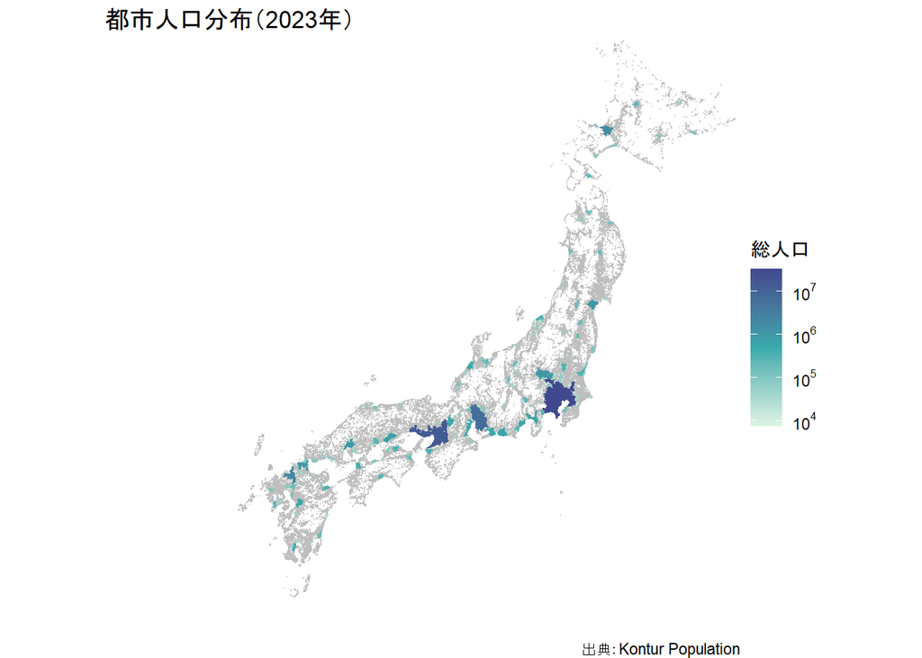

```r
ggplot() +
  geom_sf(data=hexagons_g,
          fill="gray", color="gray")+
  geom_sf(data=city,
          aes(fill=total_pop, color=total_pop))+
  scale_fill_gradientn(trans="log",
                       colors=my_colors,
                       breaks=my_breaks,
                       label=label_log())+
  scale_color_gradientn(trans="log",
                        colors=my_colors,
                        breaks=my_breaks,
                        label=label_log())+
  labs(fill="総人口", color="総人口",
       caption="出典：Kontur Population")+
  ggtitle("都市人口分布（2023年）")+
  coord_sf(xlim = c(125, 145), ylim = c(30, 45))+
  theme_void()
```

# 4 都市人口密度分布の可視化

- 上では，各都市の総人口を可視化．次に，都市の人口密度（各H3セルの人口密度）を可視化．
  - 人口密度の条件を満たすオブジェクト（`hexagons_r`）から総人口の条件（`city`）を満たすオブジェクト（`hexagons_d`）を作成．
  - `city`のジオメトリは`hexagons_r`に合わないため，削除（`st_drop_geometry()`）．オブジェクトを`city_d`とする．
- `semi_join()`：`hexagons_r`から`city_d`の条件を満たす行を両方に含まれる`city_id`を基に取り出す．

```r
#ジオメトリの削除
city_d <- city  %>%
  st_drop_geometry()

hexagons_d <- hexagons_r %>%
  semi_join(city_d, by="city_id")
```

**可視化**

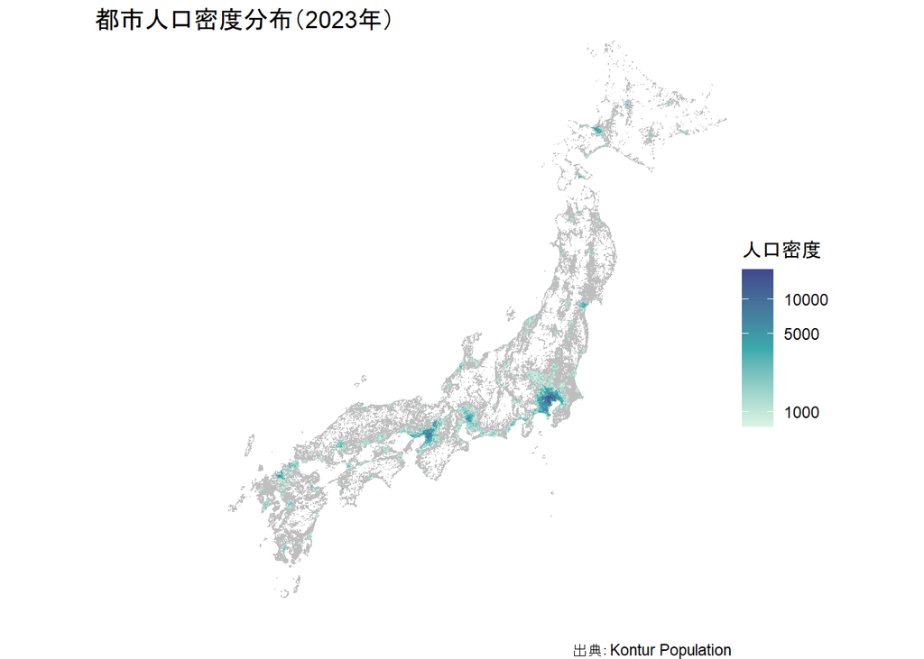

```r
#人口密度の目盛り
my_breaks2 <- c(1000, 5000, 10000)

#可視化
ggplot()+
  geom_sf(data=hexagons_g,
          fill="gray", color="gray")+
  geom_sf(data=hexagons_d,
          aes(fill=population,
              color=population))+
  scale_fill_gradientn(trans="log",
                       colors=my_colors,
                       breaks=my_breaks2)+
  scale_color_gradientn(trans="log",
                        colors=my_colors,
                        breaks=my_breaks2)+
  labs(fill="人口密度", color="人口密度",
       caption="出典：Kontur Population")+
  ggtitle("都市人口密度分布（2023年）")+
  coord_sf(xlim= c(125, 145),
           ylim=c(30, 45))+
  theme_void()
```

# 5 ランク・サイズ分布の可視化

```r
#結節地域の総人口740人以上
rank_size <- hexagons_c %>%
  filter(total_pop >= 740)

rank_size <- rank_size %>%
  arrange(desc(total_pop)) %>%
  mutate(rank=row_number())
```

- 対数を取った総人口と対数を取った順位の間の関係を散布図と示すことで，ランク・サイズルールが成立しているかどうかを可視できる．
- `scale_x_continuous()`：横軸の調整．`trans=log`で順位の対数を取る．
- `scale_y_continuous()`：縦軸の調整．`trans=log`で総人口の対数を取る．
  - 縦軸は指数表記にしたいため，`labels=label_log()`．

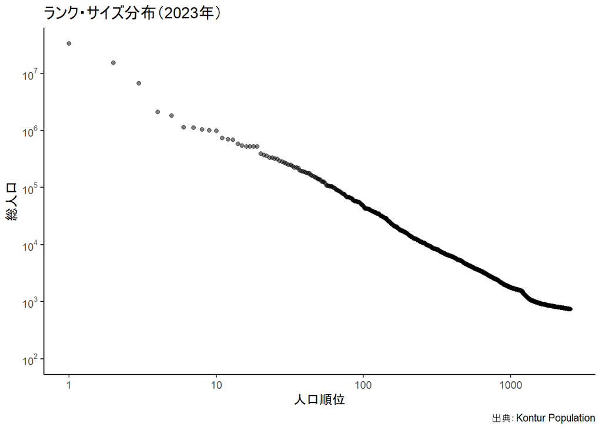

```r
#順位の目盛り
my_breaks3 <- c(1, 10, 100, 1000)

#可視化
ggplot() +
  geom_point(data=rank_size,
             aes(x=rank, y=total_pop),
             alpha=0.5) +
  scale_x_continuous(trans="log",
                     breaks=my_breaks3) +
  scale_y_continuous(trans="log",
                     breaks=my_breaks,
                     labels=label_log(),
                     limits=c(10^2, NA)) +
  labs(x="人口順位", y="総人口",
       caption="出典：Kontur Population")+
  ggtitle("ランク・サイズ分布（2023年）") +
  theme_classic()
```

- ランク・サイズ分布を見ると，ランク・サイズルール（観測値が右下がり直線上に配置）に概ね従っている．

# 参考文献・参考ウェブサイト

- 金本良嗣・徳岡一幸（2002）[「日本の都市圏設定基準」](https://www.csis.u-tokyo.ac.jp/UEA/UEADef.pdf)『応用地域学研究』No.7, 1-15．↩︎
- 森和也（アクセス日：2025-03-05）[第1話 ｢都市｣というレンズを通してみる地域経済](https://www.mori.kier.kyoto-u.ac.jp/mori-column/forecast/story01/) ↩︎
- Uber Technologies（アクセス日：2025-03-05） [Tables of Cell Statistics Across Resolutions](https://h3geo.org/docs/core-library/restable) ↩︎

# 補論

## ネットワークの可視化

- 連続するH3セルの結節地域を作成する過程で，ノードとエッジから成るネットワークを作成した．
  - ネットワークが確かにできてるかを確認．

**［1］** hexagons_rの中身

- `hexagons_r`の最初の19行目まで見ると，最初のh3セルは都市1と識別され，次の上から7つのh3セルは都市2と識別され，最後の11つのh3セルは都市3と識別されている．

| h3 | population | geom | city_id |
| --- | --- | --- | --- |
| 884ba90233fffff | 793 | POLYGON ((125.2043 24.84024… | 1 |
| 884ba900bbfffff | 836 | POLYGON ((125.2859 24.79381… | 2 |
| 884ba900b9fffff | 956 | POLYGON ((125.277 24.79438,… | 2 |
| 884ba9009dfffff | 1043 | POLYGON ((125.2794 24.80796… | 2 |
| 884ba90097fffff | 934 | POLYGON ((125.2915 24.80031… | 2 |
| 884ba90095fffff | 1036 | POLYGON ((125.2827 24.80089… | 2 |
| 884ba90091fffff | 889 | POLYGON ((125.2883 24.80739… | 2 |
| 884ba90083fffff | 849 | POLYGON ((125.2738 24.80146… | 2 |
| 884ba872c7fffff | 909 | POLYGON ((124.1432 24.34926… | 3 |
| 884ba872c1fffff | 918 | POLYGON ((124.1399 24.35633… | 3 |
| 884ba87297fffff | 1020 | POLYGON ((124.1815 24.3401,… | 3 |
| 884ba87295fffff | 1460 | POLYGON ((124.1727 24.34063… | 3 |
| 884ba87293fffff | 920 | POLYGON ((124.1871 24.34665… | 3 |
| 884ba8728dfffff | 929 | POLYGON ((124.1464 24.3422,… | 3 |
| 884ba8728bfffff | 1039 | POLYGON ((124.1607 24.34822… | 3 |
| 884ba87289fffff | 1361 | POLYGON ((124.1519 24.34874… | 3 |
| 884ba87287fffff | 1072 | POLYGON ((124.1584 24.3346,… | 3 |
| 884ba87283fffff | 1633 | POLYGON ((124.164 24.34115,… | 3 |
| 884ba87281fffff | 1364 | POLYGON ((124.1552 24.34167… | 3 |

**［2］** ネットワークの可視化

- 都市がどのように結節しているのかを可視化．
  - 確かに，都市1は1つのH3セルから，都市2は7つのH3セルから，都市3は11つのH3セルから構成されている．

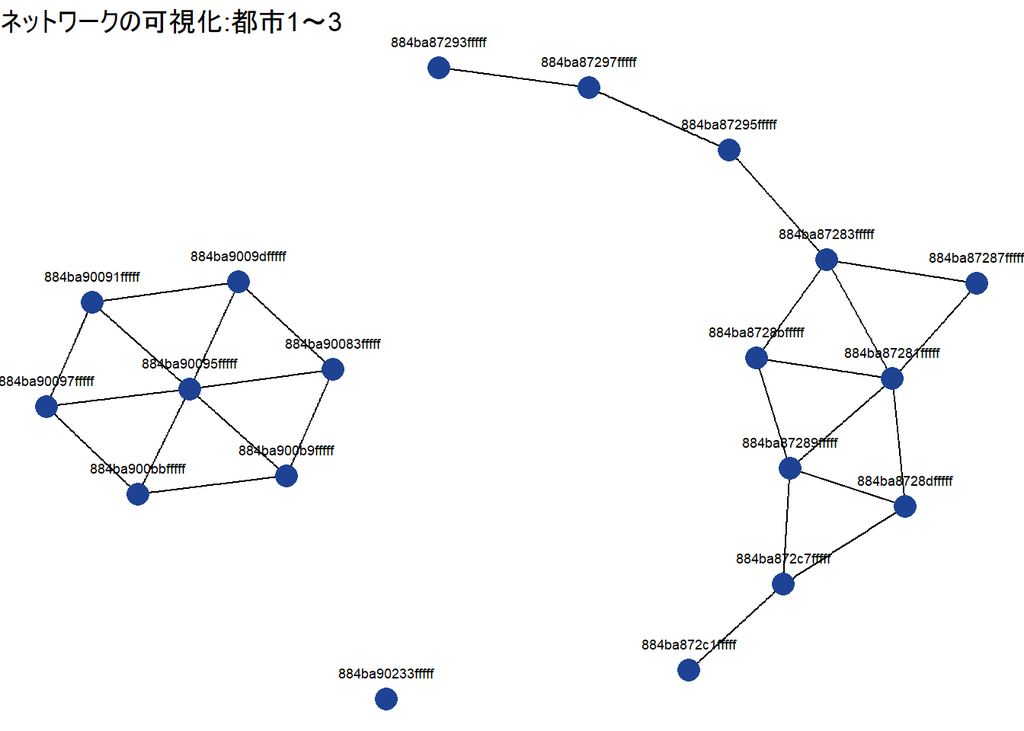

**［3］** 総人口と順位

- 都市1から都市3の総人口と順位は以下の通り．

| city_id | total_pop | geom | rank |
| --- | --- | --- | --- |
| 1 | 793 | POLYGON ((125.2043 24.84024… | 2128 |
| 2 | 6543 | POLYGON ((125.2883 24.80739… | 374 |
| 3 | 12625 | POLYGON ((124.1687 24.34316… | 223 |

## 北緯30°以南を含んだ可視化

- [人口集中地区データによる人口分布の可視化](https://shinichiro-iwata.github.io/geospatial-data-visualization/DID-pop-visualization.html)を参考に，北緯30°以南の都市の人口密度を可視化．[^1]

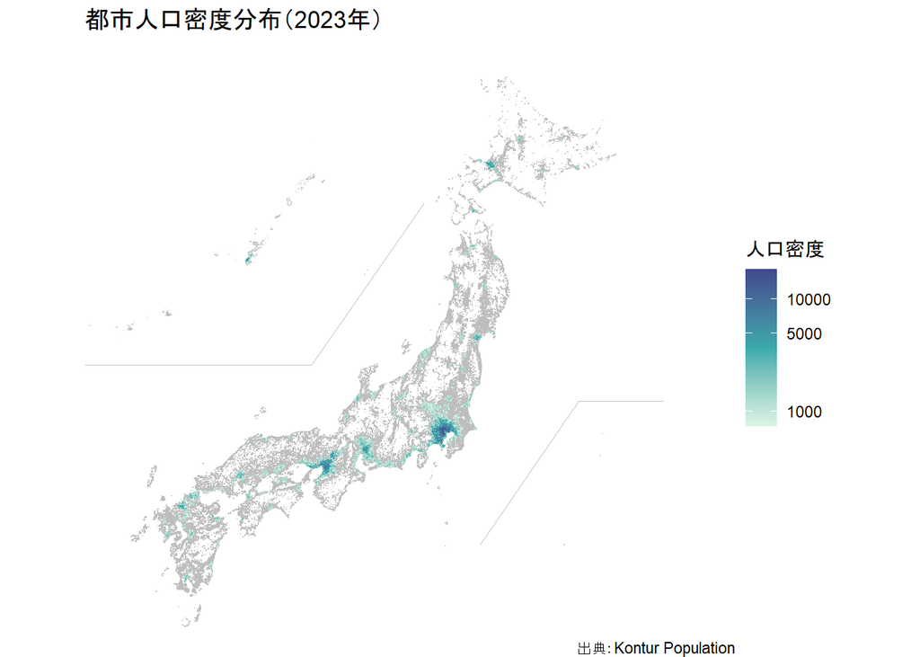

## 1都3県の可視化

1都3県（[南関東](https://ja.wikipedia.org/wiki/%E5%8D%97%E9%96%A2%E6%9D%B1)）に焦点をあてる（拡大して見る）ことにより，都市がどのように形成されているのかを確認．

- [国土数値情報](https://nlftp.mlit.go.jp/ksj/)の行政区域シェープファイルを利用して1都3県を切り抜き，都市人口分布を可視化．
  - 東京都離島を除いて，可視化．
  - 都市数は26．

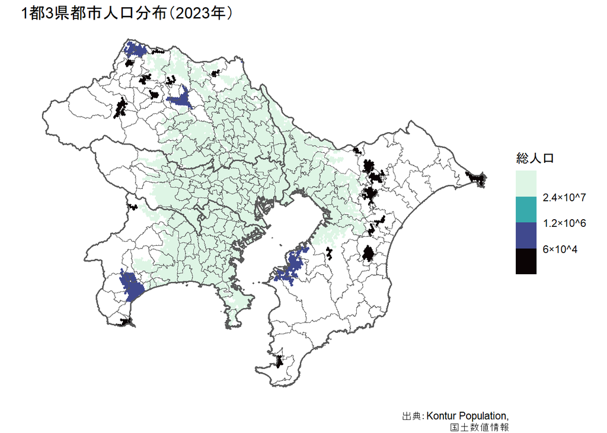

## 北東北3県の可視化

- [国土数値情報](https://nlftp.mlit.go.jp/ksj/)の行政区域シェープファイルを利用して[北東北](https://ja.wikipedia.org/wiki/%E5%8C%97%E6%9D%B1%E5%8C%97)3県（青森県，岩手県，秋田県）を切り抜き，都市人口分布を可視化．
  - 都市数は17．

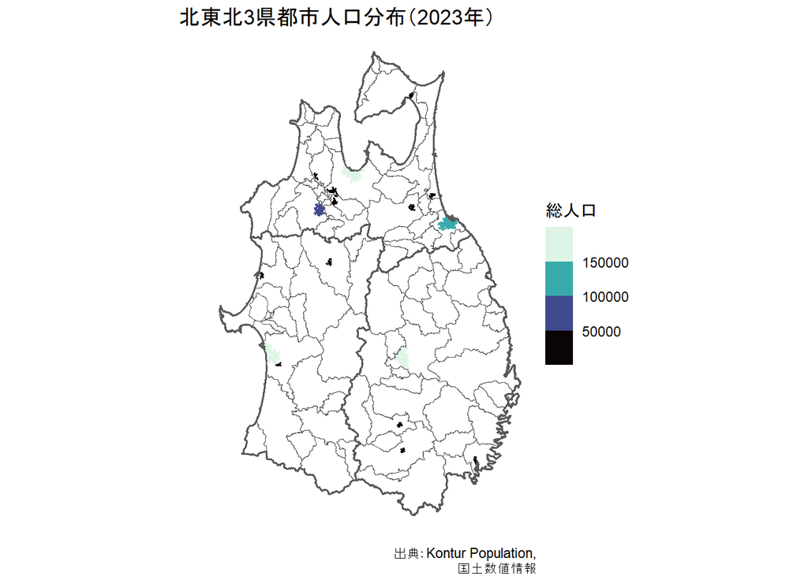

**Rによる地理空間データの可視化**

- チュートリアル[ホーム](https://shinichiro-iwata.github.io/geospatial-data-visualization/)

**アイコン**

[Font Awesome](https://fontawesome.com/) 6.7.2

**生成AIの使用について**

ChatGPTのサービスを利用した後，内容を確認し，必要に応じて編集を行った．

[^1]: 南鳥島周辺（北緯24.3度，東経154度あたり）にはH3セルが5つあるが，ここでは省略している．